# HW5_regression

##### 192STG15 조유영

### #7.2

```r
rocket <- read.csv('data-prob-7-2.csv')
rocket
```

```
##       x    y
## 1  0.25 1.42
## 2  0.50 1.39
## 3  0.75 1.55
## 4  1.00 1.89
## 5  1.25 2.43
## 6  1.50 3.15
## 7  1.75 4.05
## 8  2.00 5.15
## 9  2.25 6.43
## 10 2.50 7.89
```

#### a)

```r
fit.rocket <- lm(y~x+I(x^2), data=rocket)
summary(fit.rocket)
```

```
##
## Call:
## lm(formula = y ~ x + I(x^2), data = rocket)
##
## Residuals:
##       Min        1Q    Median        3Q       Max
## -0.005364 -0.002727  0.001045  0.002409  0.003273
##
## Coefficients:
##              Estimate Std. Error t value Pr(>|t|)
## (Intercept)  1.633000   0.004196   389.2  < 2e-16 ***
## x           -1.232182   0.007010  -175.8 5.09e-14 ***
## I(x^2)       1.494545   0.002484   601.6  < 2e-16 ***
## ---
## Signif. codes:  0 '***' 0.001 '**' 0.01 '*' 0.05 '.' 0.1 ' ' 1
##
## Residual standard error: 0.003568 on 7 degrees of freedom
## Multiple R-squared:      1,  Adjusted R-squared:      1
## F-statistic: 1.859e+06 on 2 and 7 DF,  p-value: < 2.2e-16
```

=> yhat = 1.633 -1.232*x + 1.494*x^2

#### b)

=> a)의 결과에서 F-statistic의 p-value < 0.05 이므로 유의수준 0.05 하에서 회귀직선이 유의하다.

#### c)

```r
ifelse(summary(fit.rocket)$coef[3,4]<0.05,"reject","do not reject")
```

```
## [1] "reject"
```

=> beta2의 p-value < 0.05 이므로 유의수준 0.05 하에서 H0를 기각한다. x가 있는 모형에서 x^2이 추가설명력을 지난다고 말할 수 있다.

#### d)

=> b),c)의 결과에 의해 모형에 quadratic term을 넣기로 결정하였다. quadratic term을 넣을 경우 extrapolating의 가능성이 매우 높아지게 되므로 potential harards in extrapolating이 있다고 말할 수 있다.

### #7.6

```r
beverage <- read.csv('data-prob-7-6.csv')
beverage
```

```
##        y   x1   x2
## 1   2.60 31.0 21.0
## 2   2.40 31.0 21.0
## 3  17.32 31.5 24.0
## 4  15.60 31.5 24.0
## 5  16.12 31.5 24.0
## 6   5.36 30.5 22.0
## 7   6.19 31.5 22.0
## 8  10.17 30.5 23.0
## 9   2.62 31.0 21.5
## 10  2.98 30.5 21.5
## 11  6.92 31.0 22.5
## 12  7.06 30.5 22.5
```

#### a)

```r
fit.beverage <- lm(y~x1+x2+I(x1^2)+I(x2^2)+x1*x2, data=beverage)
summary(fit.beverage)
```

```
##
## Call:
## lm(formula = y ~ x1 + x2 + I(x1^2) + I(x2^2) + x1 * x2, data = beverage)
##
## Residuals:
##      Min       1Q   Median       3Q      Max
## -0.75548 -0.22238 -0.00342  0.26024  0.96452
##
## Coefficients:
##              Estimate Std. Error t value Pr(>|t|)
## (Intercept) 3025.3186  2045.7464   1.479   0.1897
## x1          -194.2729   132.0643  -1.471   0.1917
## x2            -6.0507    20.6063  -0.294   0.7789
## I(x1^2)        3.6259     2.2098   1.641   0.1519
## I(x2^2)        1.1542     0.3237   3.565   0.0118 *
## x1:x2         -1.3317     0.8962  -1.486   0.1878
## ---
## Signif. codes:  0 '***' 0.001 '**' 0.01 '*' 0.05 '.' 0.1 ' ' 1
##
## Residual standard error: 0.6194 on 6 degrees of freedom
## Multiple R-squared:  0.9933, Adjusted R-squared:  0.9877
## F-statistic: 177.2 on 5 and 6 DF,  p-value: 1.983e-06
```

=> yhat = 3025.32 - 194.27*x1 - 6.05*x2 + 3.63*x1^2 + 1.15*x2^2 - 1.33*x1*x2

#### b)

=> a)의 결과에서 F-statistic의 p-value < 0.05 이므로 유의수준 0.05 하에서 회귀직선이 유의하다.

#### c)

```r
library(alr3)
pureErrorAnova(fit.beverage)
```

```
## Analysis of Variance Table
##
## Response: y
##              Df  Sum Sq Mean Sq  F value    Pr(>F)
## x1            1 109.964 109.964 209.2878 0.0007160 ***
## x2            1 224.101 224.101 426.5166 0.0002483 ***
## I(x1^2)       1   0.198   0.198   0.3777 0.5822831
## I(x2^2)       1   4.776   4.776   9.0904 0.0569837 .
## x1:x2         1   0.847   0.847   1.6125 0.2936949
## Residuals     6   2.302   0.384
##  Lack of fit  3   0.726   0.242   0.4605 0.7296917
##  Pure Error   3   1.576   0.525
## ---
## Signif. codes:  0 '***' 0.001 '**' 0.01 '*' 0.05 '.' 0.1 ' ' 1
```

=> LOF의 p-value > 0.05이므로 Lack of Fit이 발생했다고 보기 어렵다.

#### d)

```r
ifelse(summary(fit.beverage)$coef[6,4]<0.05, "reject", "do not reject")
```

```
## [1] "do not reject"
```

=> 교호작용항의 p-value > 0.05 이므로 유의수준 0.05하에서 귀무가설을 기각할 수 없다. 즉, 교호작용항은 유의하지 않다고 말할 수 있다.

#### e)

```r
# x1^2
ifelse(summary(fit.beverage)$coef[4,4]<0.05, "reject", "do not reject")
```

```
## [1] "do not reject"
```

=> x1^2의 p-value > 0.05 이므로 유의수준 0.05하에서 귀무가설을 기각할 수 없다. 즉, x1^2은 유의하지 않다고 말할 수 있다.

```r
# x2^2
ifelse(summary(fit.beverage)$coef[5,4]<0.05, "reject", "do not reject")
```

```
## [1] "reject"
```

=> x2^2의 p-value < 0.05 이므로 유의수준 0.05하에서 귀무가설을 기각한다. 즉, x2^2은 유의하다고 말할 수 있다.

### #7.7

```r
res <- resid(fit.beverage)
res
```

```
##           1           2           3           4           5           6
##  0.25881102  0.05881102  0.96452306 -0.75547694 -0.23547694  0.43013477
##           7           8           9          10          11          12
##  0.02643082 -0.03327942 -0.58215633 -0.17884546  0.26453429 -0.21800988
```

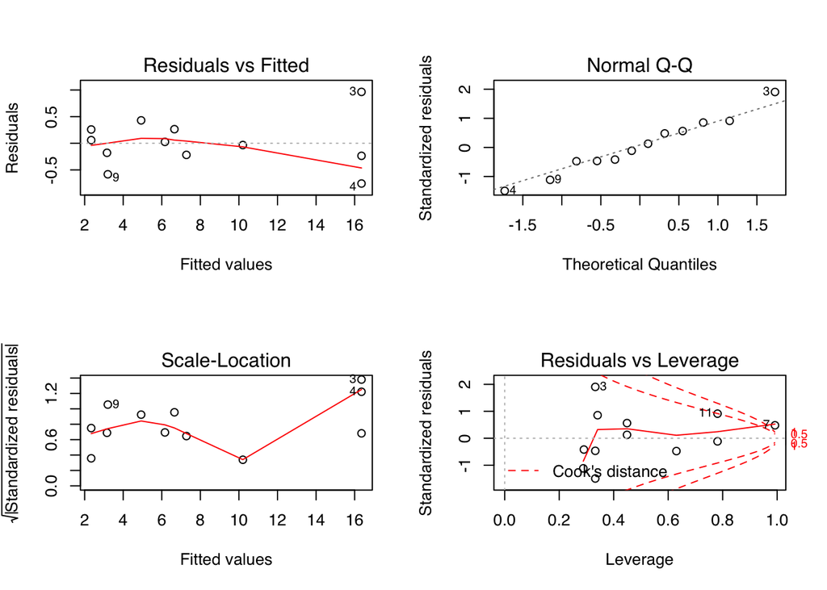

```r
par(mfrow=c(2,2))
plot(fit.beverage)
```

```r
par(mfrow=c(1,1))
```

=> Normal Q-Q plot과 residual graph 상으로는 정규성 가정을 만족하고 잔차들이 수평밴드 내에서 랜덤하게 분포하고 있어보인다.  
Cook’s distance 그래프 상에서 7번째 자료점이 영향력이 있어보인다.

### #7.8

#### a)

```r
attach(rocket)
#(x - mean(x))/0.25
lambda1 <- 2
P1 <- (x - mean(x))/0.25*lambda1

#((x - mean(x))/0.25)^2-99/12
lambda2 <- 1/2
P2 <- (((x - mean(x))/0.25)^2-99/12)*lambda2

fit.rocket.ortho <- lm(y~P1+P2, data=rocket)
summary(fit.rocket.ortho)
```

```
##
## Call:
## lm(formula = y ~ P1 + P2, data = rocket)
##
## Residuals:
##       Min        1Q    Median        3Q       Max
## -0.005364 -0.002727  0.001045  0.002409  0.003273
##
## Coefficients:
##              Estimate Std. Error t value Pr(>|t|)
## (Intercept) 3.5350000  0.0011282  3133.4   <2e-16 ***
## P1          0.3597273  0.0001964  1831.7   <2e-16 ***
## P2          0.1868182  0.0003105   601.6   <2e-16 ***
## ---
## Signif. codes:  0 '***' 0.001 '**' 0.01 '*' 0.05 '.' 0.1 ' ' 1
##
## Residual standard error: 0.003568 on 7 degrees of freedom
## Multiple R-squared:      1,  Adjusted R-squared:      1
## F-statistic: 1.859e+06 on 2 and 7 DF,  p-value: < 2.2e-16
```

```r
detach(rocket)
```

=> yhat = 3.535 + 0.3597*P1(x) + 0.1868*P2(x)

#### b)

```r
fit.rocket.cubic <- lm(y~x+I(x^2)+I(x^3),data=rocket)
summary(fit.rocket.cubic)
```

```
##
## Call:
## lm(formula = y ~ x + I(x^2) + I(x^3), data = rocket)
##
## Residuals:
##        Min         1Q     Median         3Q        Max
## -0.0052448 -0.0011538  0.0008042  0.0021154  0.0025874
##
## Coefficients:
##              Estimate Std. Error t value Pr(>|t|)
## (Intercept)  1.640000   0.006559 250.032 2.76e-13 ***
## x           -1.257016   0.019666 -63.920 9.86e-10 ***
## I(x^2)       1.516084   0.016225  93.439 1.01e-10 ***
## I(x^3)      -0.005221   0.003892  -1.342    0.228
## ---
## Signif. codes:  0 '***' 0.001 '**' 0.01 '*' 0.05 '.' 0.1 ' ' 1
##
## Residual standard error: 0.00338 on 6 degrees of freedom
## Multiple R-squared:      1,  Adjusted R-squared:      1
## F-statistic: 1.381e+06 on 3 and 6 DF,  p-value: < 2.2e-16
```

=> x^3 회귀계수의 p-value > 0.05이므로 유의수준 0.05 하에서 x^3 항이 유의하지 않음을 알 수 있다.

### #7.16

#### a)

```r
summary(fit.rocket)
```

```
##
## Call:
## lm(formula = y ~ x + I(x^2), data = rocket)
##
## Residuals:
##       Min        1Q    Median        3Q       Max
## -0.005364 -0.002727  0.001045  0.002409  0.003273
##
## Coefficients:
##              Estimate Std. Error t value Pr(>|t|)
## (Intercept)  1.633000   0.004196   389.2  < 2e-16 ***
## x           -1.232182   0.007010  -175.8 5.09e-14 ***
## I(x^2)       1.494545   0.002484   601.6  < 2e-16 ***
## ---
## Signif. codes:  0 '***' 0.001 '**' 0.01 '*' 0.05 '.' 0.1 ' ' 1
##
## Residual standard error: 0.003568 on 7 degrees of freedom
## Multiple R-squared:      1,  Adjusted R-squared:      1
## F-statistic: 1.859e+06 on 2 and 7 DF,  p-value: < 2.2e-16
```

```r
library(car)
vif(fit.rocket)
```

```
##        x   I(x^2)
## 19.90625 19.90625
```

=> vif >= 10 이므로 multicollinearity 문제가 있다고 할 수 있다.

#### b)

```r
attach(rocket)
x.centered <- x-mean(x)
fit.rocket.centered <- lm(y~x.centered+I(x.centered^2), data=rocket)
vif(fit.rocket.centered)
```

```
##      x.centered I(x.centered^2)
##               1               1
```

```r
detach(rocket)
```

=> vif < 10 이므로 multicollinearity 문제가 없다고 할 수 있다.

#### c)

=> centering 시키기 전에 비해 후의 vif 값이 현저 줄었으므로, centering 시키는 것이 multicollinerity를 해결할 수 있는 방법 중 하나임을 알 수 있다.